Annelids Brachiopods Bryozoa Chaetognaths Cnidarians Crustaceans Ctenophores Echinodermata Fishes Mammals Molluscs Nemerteans Nodding heads Phoronida Platyhelminthes Sipuncula Sponges Tunicata

# Cnidarians

[interactive chart not shown]

Antranig Basman, Charlie Gibbs, Donna Gibbs, Andy Lamb, Andrew Simon

May 13th, 2023

## Galiano Island’s cnidarian diversity

*‘Cnidaria’ is the Latinised plural form of the Greek κνίδη (knidē), which means “nettle.”*

Cnidaria comprise 12,000 extant invertebrate species which primarily occur in marine environments. The phylum is characterised by the possession of a cell called the cnidocyte, which is used for protection or prey capture. Cnidarians may be polypoid, medusoid or alternate between life stages and are grouped into seven classes: Anthozoa (anemones, soft corals, stony corals and sea fans), Cubozoa (box jellies), Hydrozoa (hydrozoans), Myxozoa (obligate parasites), Polypodiozoa (endocellular parasite), Scyphozoa (true jellyfish) and Staurozoa (stalked jellyfishes). Nearly 600 cnidarian species are known to occur along the Pacific coast of North America, over 200 of which are reported for the coast of British Columbia. Of these taxa, 77 species are reported in the Galiano Island record.

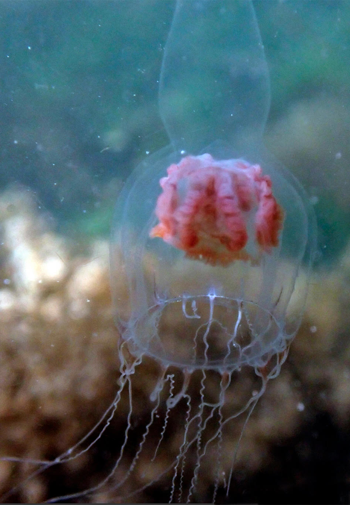

*Leuckartiara longicalcar* – Photograph by Karolle Wall

Interesting cnidarians in the Galiano Island record include the recently-described hydroids *Leuckartiara longicalcar* and *Similiclava nivea*, the latter of which represents a novel family of athecate hydrozoan. Notable historical reports include the pink helmit hydrozoan (*Aglantha digitale*) and the non-native striped green sea anemone (*Diadumene lineata*), both collected from Galiano Island in 1859 by Alexander Agassiz

[interactive chart not shown]

## Community science contributions

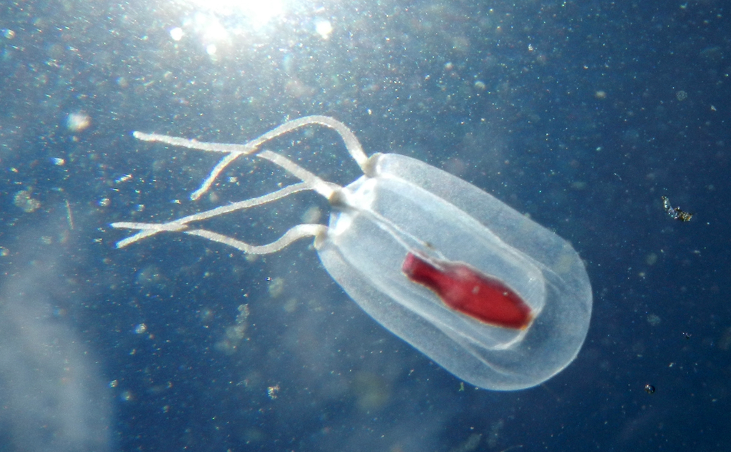

*Euphysa* sp. – Photograph by Karolle Wall

The alternation between polypoid and medusoid generations has historically resulted in a great deal of confusion in the classification of cnidarians. Hydroids, in particular, have received little recent taxonomic attention, with the most substantive revisions dating to Fraser (1937). Other reported taxa require further study to resolve their taxonomy. For instance, recent molecular analysis of *Aequorea* in the Northeast Pacific show they belong to a complex (here reported as *Aequorea victoria* s. lat.), with many other taxa potentially included within this clade. Within *Alcyonium*, two taxa are recognised in the region, though they have yet to be circumscribed. *Euphysa* also likely represents a complex, the diversity of which has yet to be determined in our region.

[interactive chart not shown]

## Top community contributions to our knowledge of the island cnidarian diversity

Please help contribute to the growing record of the island cnidarian diversity by submitting your observations to the [Biodiversity Galiano iNaturalist project.](http://inaturalist.org/projects/biodiversity-galiano-island) Here, you can browse photos of cnidarians commonly documented around Galiano Island, as well as recent observations, most favourited observations, and top observers, based on [iNaturalist](http://inaturalist.org/) data.

[interactive chart not shown]

## Sources

[Simon, A. D., Adamczyk, E. M., Basman, A., Chu, J. W., Gartner, H. N., Fletcher, K., … & Starzomski, B. M. (2022). Toward an atlas of Salish Sea biodiversity: the flora and fauna of Galiano Island, British Columbia, Canada. Part I. Marine zoology. Biodiversity Data Journal, 10.](https://bdj.pensoft.net/article/76050/)